# Forsyth County comparisons

Shane Orr

8/7/2019

```r
library(tidycensus)
library(FFtools)
library(tigris)
library(rgeos)
library(sp)
library(raster)
library(Hmisc)
library(knitr)
library(distances)
library(kableExtra)
library(gridExtra)
library(heatmaply)
library(tidyverse)

# needed so that the dplyr select function overrides the raster select function

select <- dplyr::select
```

## Data Import and cleaning

*This section imports and cleans the data. Skip down to the `Data Analysis` section if your not interested.*

All the data and shape files are imported from the Census API. As a result, the code should run as-is.

#### Find out which places are in what counties

Our first task is to connect places and counties. We’ll do this through the following process:

1. Import NC county and place shape files;
2. Calculate whether places are wholly contained within counties, and if so assign the place to that county;
3. For places not wholly contained withing counties and containing over 15,000 people, manually assign.

```r
# find out which places are in which counties -------------------------

# download place and county shape files from census API
plc <- places(state = "NC")
cnty <- counties(state = "NC")

# calculate whether places are wholly contained within counties
# store results in list, where each list element is a different county
# and the element shows all places within the county
county_places <- gContains(cnty, plc, byid=TRUE, returnDense=FALSE)

places_counties <- function(county) {

  # if there are no palces in the county (value is null) then enter NA in data frame
  # otherwise, enter the palces
  places_within <- if (is.null(county_places[[county]])) NA else county_places[[county]]

  data.frame(county = county,
             place = places_within)
}

# create single long dataframe where each row is a place / county
# combination
place_long <- map_df(seq_along(county_places), places_counties)

# the places and counties are currently identified by numbers, which represent row
# numbers in the original dataframes we want to add labels

# create dataframes that are the only the row numebrs and labels of the places
# and counties, these will then be merged on to the places_long dataframe
# these dataframes serve as lookup tables between numbers and names
convert_to_names <- function(df, col_name) {

  df <- df[c("GEOID", "NAME")]
  colnames(df) <- c("GEOID", col_name)
  df$row_num <- seq(1, nrow(df))
  return(df)

}

# create lookup tables
place_names <- convert_to_names(plc@data, "place_name")
county_names <- convert_to_names(cnty@data, "county_name")

# merge lookup tables that contain names with table that contains numbers
# and which places are within what counties
place_table <- place_long %>%
  left_join(county_names, by = c("county" = "row_num")) %>%
  left_join(place_names, by = c("place" = "row_num")) %>%
  select(-county, -place) %>%
  rename(GEOID_county = GEOID.x, GEOID_place = GEOID.y)

# population ---------------------------------

# load census variable names
# needed so we can identify which tables and variables to pull
datasets <- c("acs1", "acs1/subject", "acs1/profile")

vars <- map_df(datasets, function(x) load_variables(year = 2017, dataset = x))

# import county and place population datasets -------------------

# import palce and identify largest population place in each county
pop_place <- get_acs(geography = "place",
                     state = 'nc',
                     year = 2017,
                     table = "DP05") %>%
                 mutate(geography = "place") %>%
  # merge variable descriptions
  left_join(vars, by = c("variable" = "name"))

# identify largest palce in county
place_total_pop <- pop_place %>%
  # isolate total place populations
  filter(label == "Estimate!!SEX AND AGE!!Total population") %>%
  # join county lookup table, so we know what county the palce is in
  left_join(place_table, by = c("GEOID" = "GEOID_place")) %>%
  select(-place_name)

# we'll manually add counties to cities with population over 10000 and werent matched
# these represent places in more than one county
manual_add_county <- place_total_pop %>%
  filter((is.na(county_name) & estimate > 15000)) %>%
  select(GEOID)

add_counties <- c(37001, 37183, 37135, 37101, 37063, 37139, 37035,37081,
                  37025, 37067, 37179, 37183, 37183, 37065, 37057, 37069)

manual_add_county$GEOID_county <- add_counties

# add missing county values
place_total_pop <- place_total_pop %>%
  left_join(manual_add_county, by = "GEOID") %>%
  mutate(GEOID_county.x = ifelse(is.na(GEOID_county.x), GEOID_county.y, GEOID_county.x)) %>%
  select(-GEOID_county.y) %>%
  rename(GEOID_county = GEOID_county.x) %>%
  # now we need to add the county names for these missing values
  left_join(county_names, by = c("GEOID_county" = "GEOID")) %>%
  mutate(county_name.x = ifelse(is.na(county_name.x), county_name.y, county_name.x)) %>%
  select(-county_name.y, -row_num) %>%
  rename(county_name = county_name.x)
```

#### Select most populated place in each county

Now, we’ll select the most populated city within each county.

```r
# select most populated city in each county
city_county_lookup <- place_total_pop %>%
  group_by(GEOID_county) %>%
  # create column showing the most populated city
  mutate(most_pop = max(estimate)) %>%
  # filter for this population
  filter(estimate == most_pop,
         # remove NA
         !is.na(GEOID_county)) %>%
  ungroup() %>%
  select(GEOID, NAME, GEOID_county, county_name, estimate)

# filter our primary dataset to only keep the most populace places
pop_place <- pop_place %>%
  filter(GEOID %in% city_county_lookup$GEOID) %>%
  # add county to dataset
  left_join(city_county_lookup[, c("GEOID", "GEOID_county", "county_name")], by = "GEOID")

# remove unneeded items
rm(county_places, manual_add_county, place_long, place_names, place_table,
   place_total_pop, add_counties, county_names)
```

And here is a list of the most populated place in each county:

```r
pop_place %>%
  select(NAME, county_name) %>%
  unique() %>%
  kable(col.names = c("place name", "county name")) %>%
  kable_styling("striped", full_width = F)
```

| place name | county name |
| --- | --- |
| Ahoskie town, North Carolina | Hertford |
| Albemarle city, North Carolina | Stanly |
| Andrews town, North Carolina | Cherokee |
| Asheboro city, North Carolina | Randolph |
| Asheville city, North Carolina | Buncombe |
| Banner Elk town, North Carolina | Avery |
| Bayboro town, North Carolina | Pamlico |
| Bethlehem CDP, North Carolina | Alexander |
| Boone town, North Carolina | Watauga |
| Brevard city, North Carolina | Transylvania |
| Bryson City town, North Carolina | Swain |
| Burlington city, North Carolina | Alamance |
| Burnsville town, North Carolina | Yancey |
| Camden CDP, North Carolina | Camden |
| Chapel Hill town, North Carolina | Orange |
| Charlotte city, North Carolina | Mecklenburg |
| Clayton town, North Carolina | Johnston |
| Clinton city, North Carolina | Sampson |
| Columbia town, North Carolina | Tyrrell |
| Concord city, North Carolina | Cabarrus |
| Cullowhee CDP, North Carolina | Jackson |
| Dunn city, North Carolina | Harnett |
| Durham city, North Carolina | Durham |
| Eden city, North Carolina | Rockingham |
| Edenton town, North Carolina | Chowan |
| Elizabeth City city, North Carolina | Pasquotank |
| Elizabethtown town, North Carolina | Bladen |
| Engelhard CDP, North Carolina | Hyde |
| Fayetteville city, North Carolina | Cumberland |
| Forest City town, North Carolina | Rutherford |

[output cut: 70 more lines]

#### Import county-level population data

We’ll now import county-level population data and attach it to our data set containing place-level population data of the most populated place in each county.

```r
# import county population data and merge with population

# import county data
pop_county <- get_acs(geography = "county",
                     state = 'nc',
                     year = 2017,
                     table = "DP05") %>%
  mutate(geography = "county") %>%
  # merge variable descriptions
  left_join(vars, by = c("variable" = "name"))

# stack county data to place data
pop <- bind_rows(pop_place, pop_county)
```

We now have a complete data set of county and place population data. The next section cleans up the data by demographic

#### Separate population data by demographic

1. Total population;
2. Median age;
3. Percentage white;
4. Percentage African american; and
5. Percentage Hispanic / Latino.

```r
# filter population data ------------------------

# we'll filter the data by pulling out the total population,
# race, and age data separately
# then, we will recombine

# total population
total <- pop %>%
  # isolate total place populations
  filter(label == "Estimate!!SEX AND AGE!!Total population")

# median age
age <- pop %>%
  filter(label == "Estimate!!SEX AND AGE!!Median age (years)")

# race / ethnicity
white <- pop %>%
  filter(str_detect(label, "^Percent.*!!Not Hispanic or Latino!!White alone"))

aa <- pop %>%
  filter(label == "Percent!!RACE!!One race!!Black or African American")

hisp <- pop %>%
  filter(str_detect(label, "^Percent!!HISPANIC.*of any race.$"))
```

We’ll now recombine these five data sets into one data set, so we can have a single cleaned data set. We’ll combine them as additional columns on a single data set.

```r
# recombine population data into one dataset -----------------------

# create the skeleton dataset that the other datasets will be attached to
# it will be based on the total dataset
cleaned_df <- total %>%
  select(GEOID, NAME, total_pop = estimate, total_moe = moe, GEOID_county, county_name)

# create a function to merge the other datasets to the cleaned on
merge_demo <- function(df, estimate_col, moe_col) {

  df <- df %>%
    select(GEOID, estimate, moe)

  colnames(df) <- c("GEOID", estimate_col, moe_col)

  cleaned <- cleaned_df %>%
    left_join(df, by = "GEOID")

  return(cleaned)

}
cleaned_df <- merge_demo(age, "age_pop", "age_moe")
cleaned_df <- merge_demo(white, "white_perc", "white_moe")
cleaned_df <- merge_demo(aa, "aa_perc", "aa_moe")
cleaned_df <- merge_demo(hisp, "hisp_perc", "hisp_moe")

kable(head(cleaned_df))
```

| GEOID | NAME | total_pop | total_moe | GEOID_county | county_name | age_pop | age_moe | white_perc | white_moe | aa_perc | aa_moe | hisp_perc | hisp_moe |
| --- | --- | --- | --- | --- | --- | --- | --- | --- | --- | --- | --- | --- | --- |
| 3700500 | Ahoskie town, North Carolina | 4895 | 35 | 37091 | Hertford | 34.9 | 4.9 | 27.3 | 3.8 | 65.6 | 3.6 | 4.6 | 2.3 |
| 3700680 | Albemarle city, North Carolina | 15874 | 36 | 37167 | Stanly | 42.5 | 1.8 | 65.9 | 3.2 | 23.5 | 2.6 | 5.8 | 2.0 |
| 3701380 | Andrews town, North Carolina | 1971 | 407 | 37039 | Cherokee | 31.0 | 7.3 | 81.8 | 8.2 | 1.0 | 1.4 | 8.4 | 7.2 |
| 3702080 | Asheboro city, North Carolina | 25863 | 42 | 37151 | Randolph | 38.8 | 1.7 | 61.2 | 3.3 | 12.2 | 1.9 | 23.5 | 3.2 |
| 3702140 | Asheville city, North Carolina | 89318 | 43 | 37021 | Buncombe | 38.6 | 0.7 | 77.9 | 1.4 | 12.0 | 1.0 | 5.9 | 1.0 |
| 3703500 | Banner Elk town, North Carolina | 1451 | 409 | 37011 | Avery | 21.6 | 1.9 | 83.5 | 8.5 | 3.2 | 2.6 | 9.9 | 6.9 |

#### Separate places and counties as different columns

Right now, our data set is stacked, meaning places and counties are in the same columns. We want them in different columns.

```r
# break off places as rows and add as columns -------------------

# create separate dataframes of jsut places and counties
places <- cleaned_df %>%
  filter(!is.na(GEOID_county))

county <- cleaned_df %>%
  filter(is.na(GEOID_county)) %>%
  select(-GEOID_county, -county_name)

# merge places and county dataframes back into cleaned dataframe
cleaned_df <- left_join(places, county, by = c("GEOID_county"="GEOID"),
                   suffix = c(".place", ".county")) %>%
  select(-NAME.county) %>%
  select(GEOID_place = GEOID, place_name = NAME.place, GEOID_county, county_name, everything())

rm(total, age, white, aa, hisp, pop_county, pop)

kable(head(cleaned_df))
```

| GEOID_place | place_name | GEOID_county | county_name | total_pop.place | total_moe.place | age_pop.place | age_moe.place | white_perc.place | white_moe.place | aa_perc.place | aa_moe.place | hisp_perc.place | hisp_moe.place | total_pop.county | total_moe.county | age_pop.county | age_moe.county | white_perc.county | white_moe.county | aa_perc.county | aa_moe.county | hisp_perc.county | hisp_moe.county |
| --- | --- | --- | --- | --- | --- | --- | --- | --- | --- | --- | --- | --- | --- | --- | --- | --- | --- | --- | --- | --- | --- | --- | --- |
| 3700500 | Ahoskie town, North Carolina | 37091 | Hertford | 4895 | 35 | 34.9 | 4.9 | 27.3 | 3.8 | 65.6 | 3.6 | 4.6 | 2.3 | 24262 | NA | 42.4 | 0.6 | 33.6 | 0.1 | 58.0 | 1.8 | 3.7 | NA |
| 3700680 | Albemarle city, North Carolina | 37167 | Stanly | 15874 | 36 | 42.5 | 1.8 | 65.9 | 3.2 | 23.5 | 2.6 | 5.8 | 2.0 | 60875 | NA | 42.4 | 0.4 | 81.2 | 0.1 | 11.1 | 0.4 | 4.0 | NA |
| 3701380 | Andrews town, North Carolina | 37039 | Cherokee | 1971 | 407 | 31.0 | 7.3 | 81.8 | 8.2 | 1.0 | 1.4 | 8.4 | 7.2 | 27463 | NA | 50.8 | 0.4 | 91.5 | 0.2 | 1.4 | 0.3 | 3.0 | NA |
| 3702080 | Asheboro city, North Carolina | 37151 | Randolph | 25863 | 42 | 38.8 | 1.7 | 61.2 | 3.3 | 12.2 | 1.9 | 23.5 | 3.2 | 142827 | NA | 41.5 | 0.3 | 79.7 | 0.1 | 6.3 | 0.3 | 11.1 | NA |
| 3702140 | Asheville city, North Carolina | 37021 | Buncombe | 89318 | 43 | 38.6 | 0.7 | 77.9 | 1.4 | 12.0 | 1.0 | 5.9 | 1.0 | 252268 | NA | 41.9 | 0.3 | 83.7 | 0.1 | 6.3 | 0.3 | 6.4 | NA |
| 3703500 | Banner Elk town, North Carolina | 37011 | Avery | 1451 | 409 | 21.6 | 1.9 | 83.5 | 8.5 | 3.2 | 2.6 | 9.9 | 6.9 | 17535 | NA | 44.5 | 0.6 | 89.0 | 0.1 | 4.2 | 0.6 | 5.1 | NA |

#### Calculate population density

We will account for urban and rural through population density. We’ll take the following steps to calculate population density:

1. Calculate the area in square kilometers of each county and place, and
2. Divide the county or place’s population by the area to compute the density per square kilometer.

```r
# find population density ------------------------------------

# calculate areas of counties and places and palce in data frame
# use function for both

calc_area <- function(spatial_object) {

  data.frame(
    GEOID = spatial_object@data$GEOID,
    name = spatial_object@data$NAME,
    area = area(spatial_object) / 1000000 # area in sq kilometers
  )

}

cnty_areas <- calc_area(cnty)
place_areas <- calc_area(plc)

# merge county and place areas to final dataset,
# so we can calculate population densities
# we'll also log populations while we're here
pop_dens <- cleaned_df %>%
  left_join(place_areas[c("GEOID", "area")], by = c("GEOID_place" = "GEOID")) %>%
  mutate(total_pop_log.place = log(total_pop.place),
         pop_density.place = total_pop.place / area,
         pop_density_log.place = total_pop_log.place / area) %>%
  select(-area) %>%
  left_join(cnty_areas[c("GEOID", "area")], by = c("GEOID_county" = "GEOID")) %>%
  mutate(total_pop_log.county = log(total_pop.county),
         pop_density.county = total_pop.county / area,
         pop_density_log.county = total_pop_log.county / area) %>%
  select(-area)
```

## Data Analysis

### Exploratory analysis

#### Population skewness

Population numbers are often right skewed, as some localities have extremely large populations. Due to this, it often makes sense to log transform populations. Such a transformation can convert populations to a normal distribution.

Given this, we’ll created models with both log transformed and non-transformed population parameters.

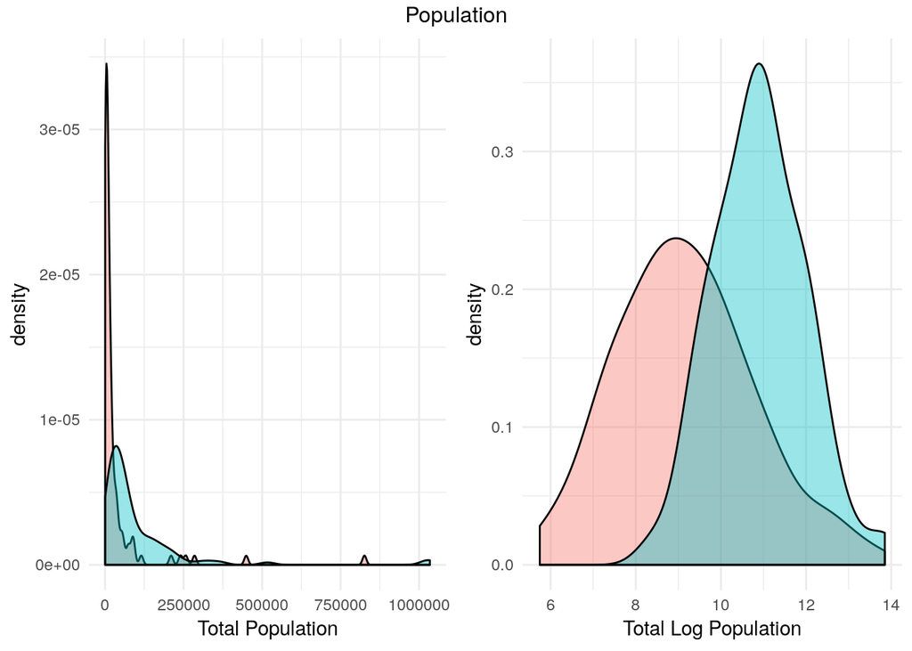

```r
# this function creates density plots
density_plot <- function(df, x_place, x_county, x_title, main_title) {

  ggplot(df) +
    geom_density(aes(x={{ x_place }}, fill="#4287f5"), alpha=0.4) +
    geom_density(aes(x={{ x_county }}, fill="#f57542"), alpha=0.4) +
    labs(x = x_title) +
    theme_minimal() +
    theme(legend.position="none")

}

pop_plot <- density_plot(pop_dens, total_pop.place, total_pop.county,
                         "Total Population")
pop_log_plot <- density_plot(pop_dens,
                              total_pop_log.place, total_pop_log.county,
                              "Total Log Population")

grid.arrange(pop_plot, pop_log_plot, nrow=1, top="Population")
```

#### Correlations

The table below shows a correlation matrix of all variables. Correlations plus or minus .9 are in red, while those plus or minus .7 are in blue.

```r
# create vectors of columns to be used
county_col <- c("age_pop.county", "white_perc.county","aa_perc.county", "hisp_perc.county")
place_col <- c("age_pop.place", "white_perc.place","aa_perc.place", "hisp_perc.place")
county_non_log <- c("total_pop.county", "pop_density.county")
place_non_log <- c("total_pop.place", "pop_density.place")
county_log <- c("total_pop_log.county", "pop_density_log.county")
place_log <- c("total_pop_log.place", "pop_density_log.place")

all_columns <- c(county_col, place_col, county_non_log, place_non_log)

rcorr(as.matrix(pop_dens[all_columns]))[["r"]] %>%
  as.data.frame() %>%
  mutate(var = colnames(.)) %>%
  select(var, everything()) %>%
  mutate_if(is.numeric, function(x) {
    cell_spec(round(x, 2),
              color = ifelse(abs(x) > .9, "red",
                             ifelse(abs(x) > .7, "blue", "black")))
  }) %>%
  kable(format = "html", escape = F) %>%
  kable_styling("striped")
```

| var | age_pop.county | white_perc.county | aa_perc.county | hisp_perc.county | age_pop.place | white_perc.place | aa_perc.place | hisp_perc.place | total_pop.county | pop_density.county | total_pop.place | pop_density.place |
| --- | --- | --- | --- | --- | --- | --- | --- | --- | --- | --- | --- | --- |
| age_pop.county | 1 | 0.41 | -0.22 | -0.45 | 0.52 | 0.29 | -0.2 | -0.08 | -0.45 | -0.46 | -0.4 | -0.55 |
| white_perc.county | 0.41 | 1 | -0.92 | -0.24 | 0.16 | 0.81 | -0.83 | 0.12 | -0.16 | -0.16 | -0.22 | -0.19 |
| aa_perc.county | -0.22 | -0.92 | 1 | 0 | -0.11 | -0.79 | 0.88 | -0.24 | 0.04 | 0.05 | 0.13 | 0.1 |
| hisp_perc.county | -0.45 | -0.24 | 0 | 1 | -0.13 | -0.32 | 0.12 | 0.5 | 0.32 | 0.34 | 0.27 | 0.24 |
| age_pop.place | 0.52 | 0.16 | -0.11 | -0.13 | 1 | 0.19 | -0.11 | -0.14 | -0.21 | -0.2 | -0.21 | -0.43 |
| white_perc.place | 0.29 | 0.81 | -0.79 | -0.32 | 0.19 | 1 | -0.93 | -0.19 | -0.12 | -0.13 | -0.16 | -0.13 |
| aa_perc.place | -0.2 | -0.83 | 0.88 | 0.12 | -0.11 | -0.93 | 1 | -0.17 | 0.02 | 0.03 | 0.08 | 0.06 |
| hisp_perc.place | -0.08 | 0.12 | -0.24 | 0.5 | -0.14 | -0.19 | -0.17 | 1 | 0.13 | 0.15 | 0.1 | 0.05 |
| total_pop.county | -0.45 | -0.16 | 0.04 | 0.32 | -0.21 | -0.12 | 0.02 | 0.13 | 1 | 0.93 | 0.94 | 0.63 |
| pop_density.county | -0.46 | -0.16 | 0.05 | 0.34 | -0.2 | -0.13 | 0.03 | 0.15 | 0.93 | 1 | 0.94 | 0.65 |
| total_pop.place | -0.4 | -0.22 | 0.13 | 0.27 | -0.21 | -0.16 | 0.08 | 0.1 | 0.94 | 0.94 | 1 | 0.58 |
| pop_density.place | -0.55 | -0.19 | 0.1 | 0.24 | -0.43 | -0.13 | 0.06 | 0.05 | 0.63 | 0.65 | 0.58 | 1 |

The African American and white variable are highly correlated, which isn’t surprising on reflection. We’ll take out African American for now. We’re taking out African American instead of white because African American estimates have wider variance.

Place and county populations are also highly correlated. So, our place and county model will only include county populations.

```r
# update columns without african american and place numbers
county_col <- c("age_pop.county", "white_perc.county", "hisp_perc.county")
place_col <- c("age_pop.place", "white_perc.place", "hisp_perc.place")
place_non_log <- c("pop_density.place")
place_log <- c("pop_density_log.place")
```

### Calculate Euclidean distances

```r
# create columns for different models
all_cols_non_log <- c(county_non_log, county_col, place_col, place_non_log)
all_cols_log <- c(county_log, county_col, place_col, place_log)
counties_non_log <- c(county_non_log, county_col)
counties_log <- c(county_log, county_col)
```

Now, we will calculate the Euclidean distances From Forsyth to all NC counties for four models with the following variables:

1. Counties and places, populations not logged:
- total_pop.county, pop_density.county, age_pop.county, white_perc.county, hisp_perc.county, age_pop.place, white_perc.place, hisp_perc.place, pop_density.place
2. Counties and places, populations logged:
- total_pop_log.county, pop_density_log.county, age_pop.county, white_perc.county, hisp_perc.county, age_pop.place, white_perc.place, hisp_perc.place, pop_density_log.place
3. Counties only, populations not logged:
- total_pop.county, pop_density.county, age_pop.county, white_perc.county, hisp_perc.county
4. Counties only, populations logged:
- total_pop_log.county, pop_density_log.county, age_pop.county, white_perc.county, hisp_perc.county

The code block below creates a function that we’ll use to run all models.

```r
# create function to calculate distances and order results
euc_dist <- function(distance_df, dist_columns, dist_weights) {

  # df <- distance_df[dist_columns] %>%
  #   mutate_all(scale) %>%
  #   as.matrix()
  df <- distance_df[dist_columns] %>%
    as.matrix()

  # this function calculates Euclidean distance
  dist <- distances(data = df,
                    normalize = "studentize",
                    weights = dist_weights
                    ) %>%
    as.matrix() %>%
    as.data.frame()

  # find which row forsyth is, so we can extract it from distance DF
  forsyth_row <- which(distance_df$county_name == "Forsyth")

  # only keep this column of distance matrix
  forsyth_dist <- dist[forsyth_row]

  # add county names to forsyth distance matrix
  forsyth_dist$county <- distance_df$county_name

  colnames(forsyth_dist) <- c("distance", "county")

  # to verify counties align, Forsyth's distance should be zero
  forsyth_dist[forsyth_dist$county == "Forsyth", ]

  # remove Forsyth and rank counties from smallest to largest
  forsyth_dist <- forsyth_dist %>%
    filter(county != "Forsyth") %>%
    arrange(distance) %>%
    select(county, distance)

  return(forsyth_dist)

}
```

Now, let’s save the model parameters and run the models. The only parameters are the variables and weights. We’ll weight all variables with a 1, but you could make a case that the two race variables should be weighted at .5, which would collectively give them the same weight as the other variables. But, I doubt this would have any impact.

```r
# create parameters for models -------

# columns for each model
dist_columns <- list(
    all_cols_non_log,
    all_cols_log,
    counties_non_log,
    counties_log
)

# create weights for models
w_all_cols <- rep(1, length(all_cols_non_log))
w_county <- rep(1, length(counties_non_log))

dist_weights <- list(
  w_all_cols,
  w_all_cols,
  w_county,
  w_county
)

# calculate distances for four models
euc_dist <- map2(dist_columns, dist_weights,
                 euc_dist, distance_df = pop_dens)
```

#### Euclidean distance final results

And here are the final results from all four models, ranks from closest to farthest:

```r
# convert into single dataframe
bind_cols(euc_dist) %>%
  kable() %>%
  kable_styling("striped") %>%
  add_header_above(c("County / Place | Non-log" = 2,
                     "County / Place | log" = 2,
                     "County | Non-log" = 2,
                     "County | log" = 2))
```

| County / Place \| Non-log county | County / Place \| Non-log distance | County / Place \| log county1 | County / Place \| log distance1 | County \| Non-log county2 | County \| Non-log distance2 | County \| log county3 | County \| log distance3 |
| --- | --- | --- | --- | --- | --- | --- | --- |
| Durham | 1.634564 | Alamance | 1.205337 | Durham | 1.256511 | Alamance | 1.026768 |
| Guilford | 2.053025 | Cabarrus | 1.371634 | Guilford | 1.636196 | Cabarrus | 1.092685 |
| Cabarrus | 2.193137 | Mecklenburg | 1.461158 | Cabarrus | 1.914363 | Mecklenburg | 1.430097 |
| Cumberland | 2.499689 | Durham | 1.722134 | Cumberland | 2.214688 | Wayne | 1.547410 |
| Alamance | 2.510935 | Wilson | 1.913214 | Gaston | 2.334239 | Durham | 1.663844 |
| Gaston | 2.629989 | Wayne | 2.007633 | Alamance | 2.428653 | Union | 1.692298 |
| Union | 2.815974 | Catawba | 2.048440 | Union | 2.428933 | Catawba | 1.694312 |
| New Hanover | 3.101085 | Guilford | 2.094027 | New Hanover | 2.450597 | Wilson | 1.695609 |
| Catawba | 3.102838 | Rowan | 2.101832 | Catawba | 2.763917 | Orange | 1.756872 |
| Johnston | 3.153813 | Gaston | 2.147114 | Johnston | 2.778187 | Guilford | 1.791370 |
| Rowan | 3.237344 | Wake | 2.194233 | Orange | 2.882577 | Harnett | 1.841493 |
| Wayne | 3.365825 | Union | 2.205136 | Wayne | 2.947929 | Gaston | 1.886302 |
| Wilson | 3.373193 | Cumberland | 2.306310 | Buncombe | 3.045679 | Rowan | 1.930999 |
| Harnett | 3.435415 | Harnett | 2.351342 | Harnett | 3.074862 | Johnston | 1.963077 |
| Iredell | 3.478118 | Johnston | 2.376864 | Rowan | 3.090104 | Wake | 2.066217 |
| Davidson | 3.508009 | Hoke | 2.650745 | Iredell | 3.113035 | Cumberland | 2.112958 |
| Buncombe | 3.699069 | Davidson | 2.703486 | Wilson | 3.229842 | Iredell | 2.233288 |
| Randolph | 3.750686 | Iredell | 2.710323 | Davidson | 3.325676 | New Hanover | 2.269720 |
| Orange | 3.966547 | Orange | 2.729280 | Pitt | 3.333625 | Franklin | 2.287144 |
| Lincoln | 3.987084 | New Hanover | 2.884090 | Randolph | 3.341656 | Lenoir | 2.340226 |
| Lee | 4.023639 | Craven | 2.889381 | Lee | 3.548306 | Nash | 2.347005 |
| Vance | 4.038308 | Randolph | 2.896734 | Nash | 3.578451 | Hoke | 2.438633 |
| Hoke | 4.043744 | Lincoln | 2.943007 | Craven | 3.602705 | Randolph | 2.460209 |
| Pitt | 4.049968 | Lee | 3.021393 | Henderson | 3.638619 | Davidson | 2.478546 |
| Robeson | 4.056036 | Franklin | 3.071075 | Franklin | 3.656654 | Granville | 2.568462 |
| Craven | 4.071734 | Vance | 3.129457 | Lenoir | 3.726354 | Pitt | 2.588139 |
| Greene | 4.135045 | Rockingham | 3.140271 | Lincoln | 3.741666 | Craven | 2.607212 |
| Pasquotank | 4.214856 | Pasquotank | 3.173342 | Onslow | 3.750626 | Henderson | 2.646076 |
| Onslow | 4.224305 | Pitt | 3.206028 | Vance | 3.782066 | Buncombe | 2.661083 |
| Sampson | 4.249076 | Robeson | 3.227808 | Robeson | 3.790006 | Lee | 2.678167 |

[output cut: 69 more lines]

#### Dendogram and heatmap

Dendogram and heatmap for counties with non-logged popualtion. All variables are scaled to have a mean of zero and sandard deviation of 1.

```r
pop_dens <- as.data.frame(pop_dens, stringsAsFactors = F)
row.names(pop_dens) <- pop_dens$county_name

heatmaply(pop_dens[c(counties_non_log, "county_name")],
          margins = c(60,100,40,20),
          xlab = "Features", ylab = "Counties", scale='column',
          main = "Dendogram heatmap of Counties non-log population")
```

[interactive chart not shown]

Here is the same plot, but with logged populations.

```r
heatmaply(pop_dens[c(counties_log, "county_name")],
          margins = c(60,100,40,20),
          xlab = "Features", ylab = "Counties", scale='column',
          main = "Dendogram heatmap of Counties log population")
```

[interactive chart not shown]